# Lezione 1 - Introduzione

Giovanni Marchetti, DISIA, Firenze

2020-02-25

## Argomenti del corso

I temi fondamentali del corso di Statistica sono esemplificati attaverso due applicazioni.

### Esempio

(Efron & Tibshirani, 1997). In un esperimento 16 topi sono suddivisi casualmente in 2 gruppi: un gruppo di animali trattati con un farmaco e un gruppo di controllo di animali non trattati. Il trattamento serve per prolungare la sopravvivenza dei topi dopo un’operazione. Al termine dell’esperimento si studia il numero di giorni di sopravvivenza dei topi.
$$\begin{array}{llcrr}
& \text{Dati} & \text{Numero} & \text{Media} & \text{errore standard} \\ \hline
Trattamento & 94, 197, 16 & & & \\
& 38, 99, 141, 23 & 7 & 86.86 & 25.24 \\
Controllo & 52, 104, 146, & & & \\
& 10, 51, 30, & 9 & & \\
& 40, 27, 46 & & 56.22 & 14.14 \\ \hline
\end{array}$$

L’obiettivo dell’esperimento è quello di valutare se il trattamento prolunga il tempo di sopravvivenza.

In questo esperimento, che non è raro nei laboratori e che implica il sacrificio di un certo numero di animali, i dati sono raccolti su due caratteri

- $Y =$ il tempo di sopravvivenza
- $X =$ il gruppo

$Y$ si può rappresentare come una variabile quantitativa e $X$ come una variabile qualitativa con due modalità: trattamento e controllo.

I dati si registrano in un data frame (R, Python, Matlab)

```r
y = c(94, 197, 16, 38, 99, 141, 23, 52,
      104, 146, 10, 51, 30, 40, 27, 46)
x = c('T','T','T','T','T','T','T','C',
      'C','C','C','C','C','C','C','C')
df = data.frame(x = x, y = y)
```

I dati si possono pensare come realizzazioni di variabili aleatorie $X$ e $Y$. Le realizzazioni hanno una struttura cioè,

$$(Y_1, \dots, Y_7) \stackrel{iid}{\sim} F
\text{ e, indipendentemente } (Y_8, \dots, Y_{16}) \stackrel{iid}{\sim} G$$

dove

- $F$ e $G$ sono due funzioni ripartizione che descrivono la sopravvivenza rispettivamente degli animali trattati e non trattati e
- il simbolo $\stackrel{iid}{\sim}$ indica che le variabili a sinistra del simbolo sono indipendenti e identicamente distribuite secondo la legge a destra del simbolo.

Le distribuzioni $F$ e $G$ non sono note e la loro legge potrebbe essere specificata in modo vago - per esempio supponendo solo che abbiano come supporto i reali positivi - oppure in modo più preciso - per esempio supponendo che siano Esponenziali.

Come possiamo valutare se il trattamento produce l’aumento della sopravvivenza? Un modo per farlo è valutare la **differenza tra le medie** della sopravvivenza nei due gruppi

$$\theta = E_F(Y) - E_G(Y) = \mu_F - \mu_G.$$

Questa quantità $\theta$ è un valore incognito perché si riferisce alle due popolazioni dei trattati e dei controlli.

L’obiettivo dunque è quello di capire quanto vale $\theta$ usando i dati sperimentali. Che metodo possiamo usare? Intuitivamente, ragionando per analogia, possiamo usare una **stima** basata sulle medie della sopravvivenza nei due gruppi sperimentali:

$$\hat \theta = \bar y_T - \bar y_C = 30.64$$

dove $\bar y_T = 86.86$ e $\bar y_C = 56.22$.

Dopo avere ottenuto questa stima (che implica 30 giorni di sopravvivenza in più per i trattati) ci si pongono 2 problemi:

D1. La stima è **affetta da errore** perché in un secondo esperimento il valore di $\hat \theta$ risulterà diverso **anche solo per effetto del caso**. Di quale entità è tale errore?

D2. Per dimostrare che il farmaco è efficace, sicuramente vogliamo **confutare** che $\mu_T = \mu_C$ cioè l’ipotesi che $\theta = 0$. Con quale procedimento possiamo farlo?

R1. Un modo per misurare l’errore è calcolare la variabilità di $\hat \theta$ nel **campionamento ripetuto**. Esistono dei metodi che consentono di calcolare e stimare la sua deviazione standard

$$\sigma(\bar y_T - \bar y_C)$$

chiamata appunto **errore standard**. In questo caso

$$\hat \sigma(\bar y_T - \bar y_C) = \sqrt{25.24^2 + 14.14^2} = 28.93.$$

R2. Un modo per confutare $\mu_T = \mu_C$ è valutare differenza tra $\bar y_T$ e $\bar y_C$ con un **test d’ipotesi**. Poiché la differenza osservata $30.63$ è in termini di errori standard solo $30.63/28.93 = 1.05$, la differenza è giudicata non significativa, perché potrebbe essere dovuta al caso.

Errori standard e test d’ipotesi sono metodi classici di inferenza statistica.

## Esempio

Talora i dati rilevati sono raccolti su due o più variabili. In uno studio sulla gestazione su $n = 610$ feti sono rilevate

- le età gestazionali $X$ e
- le circonferenze addominali $Y$.

I dati sono riassunti come sotto indicato:

```r
data('abdom', package = 'gamlss.data')
summary(abdom)
```

```
       y             x
 Min.   : 56   Min.   :12.3
 1st Qu.:153   1st Qu.:20.0
 Median :227   Median :27.0
 Mean   :227   Mean   :27.3
 3rd Qu.:304   3rd Qu.:34.4
 Max.   :404   Max.   :42.4
```

I dati sono visualizzati in un grafico cartesiano dei punti $(x_i, y_i)$ detto comunemente **scatter**.

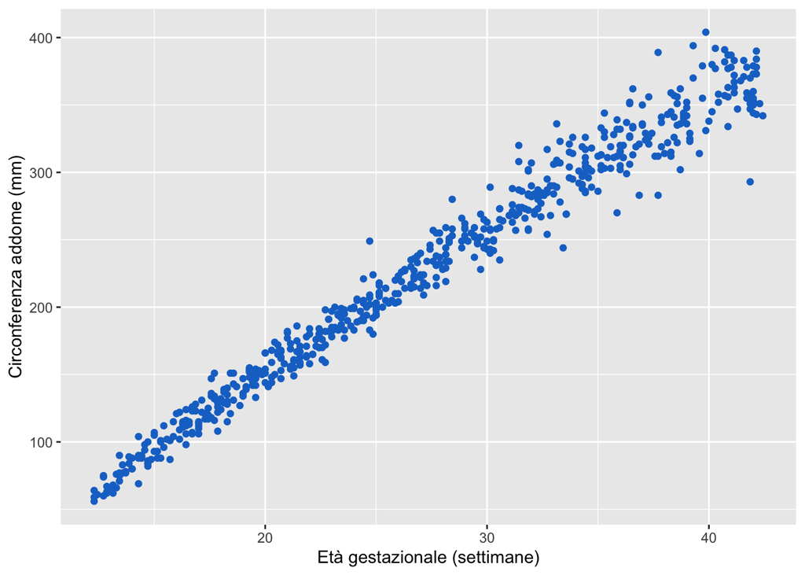

```r
require(ggplot2)
ggplot(data=abdom, aes(x, y)) + geom_point(color = 'dodgerblue3') +
       labs(x = 'Età gestazionale (settimane)',
            y = 'Circonferenza addome (mm)')
```

Il grafico evidenzia immediatamente la relazione crescente tra l’età gestazionale e la ciconferenza dell’addome. Le domande principali che si pongono sono tipicamente

- Qual è la direzione e la forza dell’associazione tra le due variabili?
- Per ogni settimana in più di gestazione di quanto cresce la circonferenza dell’addome?
- La relazione tra le due variabili può essere considerata lineare?
- Se in questo momento osserviamo una gravidanza alla 30esima settimana di gestazione qual è la circonferenza dell’addome prevista?

Si possono condiderare le variabili **sullo stesso piano** e quindi studiarne la correlazione $\text{cor}(X,Y) = \rho_{xy}$. La correlazione stimata è

$$r_{XY} = \frac{\sum_{i}(x_i - \bar x)(y_i - \bar y)}{\sqrt{\sum_i(x_i- \bar x)^2 \sum_{i}(y_i - \bar y)^2}} = 0.98$$

che indica un forte legame lineare tra la due variabili.

Oppure si possono studiare le due variabili in modo **asimmetrico** considerando $Y$ come **variabile dipendente** e $X$ come **variabile esplicativa** studiando la distribuzione condizionata di $Y$ dato $X$.

In questo secondo caso ci possono essere due finalità

- una **finalità esplicativa** con la quale si studia e si interpreta la struttura della distribuzione condizionata di $Y$ dato $X$
- una **finalità predittiva** con cui invece si cerca di prevedere nel modo migliore possibile il valore **futuro** di $Y$ dato il valore osservato di $X$.

Supponendo che le osservazioni siano realizzazioni indipendenti e identicamente distribuite di una coppia di variabili aleatorie $(X_i, Y_i)$ con una distribuzione ignota $F(x,y)$ l’oggetto principale da studiare è il **valore atteso condizionato** $r(x) = E(Y \mid X = x)$, ossia la cosiddetta **funzione di regressione**.

Talvolta come in questo esempio i dati suggeriscono che la funzione di regressione sia approssimabile con una retta

$$r(x) = \beta_0 + \beta_1 x.$$

Altre volte ha senso cercare modelli più flessibili e non lineari. L’adattamento ottimale della curva di regressione (lineare o non lineare) richiede dei metodi di stima opportuni. Nella figura sottostante è stato adattato un modello di regressione quadratico

$$r(x) = \beta_0 + \beta_1 x + \beta_2 x^2.$$

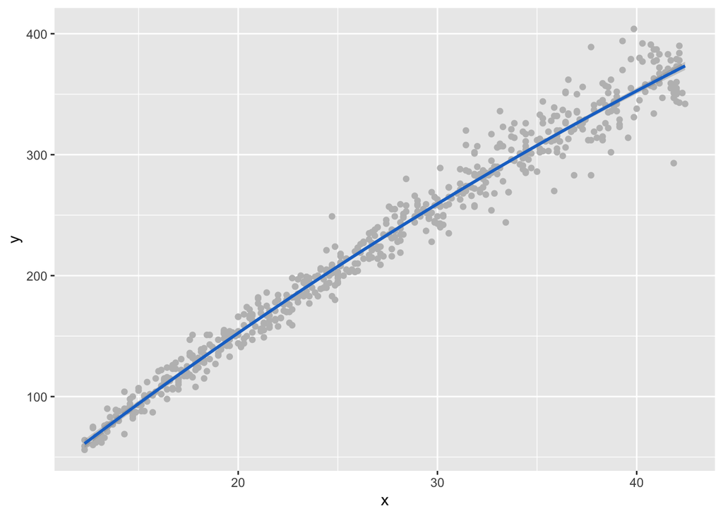

```r
ggplot(data=abdom, aes(x, y)) +
    geom_point(color = 'gray') +
    geom_smooth(method = 'lm', formula = 'y ~ x + I(x^2)', col = 'dodgerblue3')
```

## I temi fondamentali

- Abbiamo un **problema concreto** e per risolverlo raccogliamo in modo opportuno dei **dati**. Tipicamente si fanno **campioni casuali**, o **esperimenti controllati** o **esperimenti osservativi**.
- Il problema di solito riguarda un **singolo carattere** o **la relazione fra più caratteri** osservati: i caratteri vengono rappresentati da variabili aleatorie.
- La natura del problema fa sì che i dati abbiano una particolare **struttura**.
- Il tipo di caratteri studiati e la struttura dei dati suggeriscono dei **modelli probabilistici per i dati osservati** dipendenti da parametri incogniti. Ci possono essere modelli alternativi per spiegare il comportamento dei dati.
- Una prima strategia è quella di **ipotizzare un certo modello** ragionevole per il problema studiato. Il modello quindi è conosciuto a meno di certi parametri che vanno determinati partendo dai dati osservati. Questa operazione è chiamata **inferenza statistica**.
- L’inferenza statistica si è sviluppata storicamente con due impostazioni diverse: quella **frequentista** e quella **bayesiana**. Un concetto di importanza fondamentale in emtrambi gli approcci è quello di **funzione di verosimiglianza**.
- Per fare inferenza si usano delle **sintesi dei dati** che permettono di ricostruire i parametri incogniti e dei **metodi generali di inferenza** che permettono di definire delle procedure con proprietà desiderabili. Una proprietà essenziale è che le sintesi dei dati contengano tutta l’**informazione** rilevante.
- Ci sono vari tipi di inferenza possibili: (a) la **stima** dei parametri (b) la **verifica di una specifica ipotesi** su un parametro (c) la **previsione** di una delle variabili che si stanno studiando.
- Dopo aver fatto inferenza dato un modello, si rende necessaria una fase di **controllo del modello** basata sulle differenze ciò che si è osservato e ciò che si è spiegato col modello una volta ottenute le stime.
- Una strategia più complessa è infine quella che usa i dati per scoprire il modello più appropriato. Questa strategia più complessa si dice **scelta del modello** o **apprendimento della struttura**.